# GLM I - Count Regression

## Poisson Regression

## Set up

- When the response is an unbounded count (0,1,2,3…) we can use a count regression model.
- What about when count is bounded?

If *Y* is Poisson with mean \(\mu\) > 0 then:

\[ P(Y = y) = \frac{e^{-\mu}\mu^y}{y!} \\ y = 0,1,2, ... \\ EY = var Y = \mu \]

## Poisson Distribution

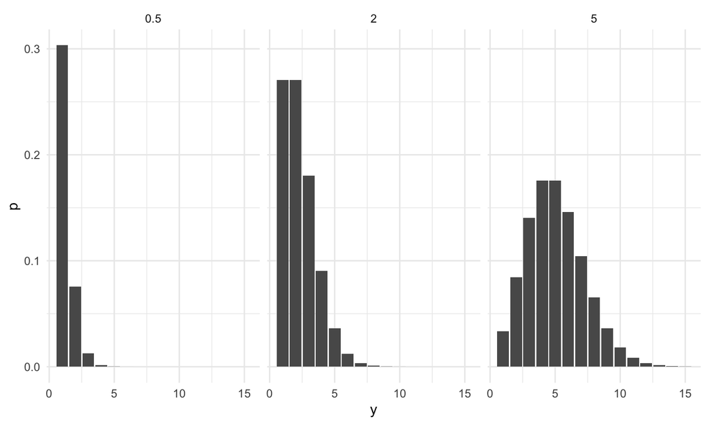

## Poisson distribution

- If count is number of possible total then binomial is better, but is a good approximation when n is large and p is small.
- Probability of event is proportional to length of time and independent of other events.
- Time between events is exponentially distributed (basically the same as above)
- Sum of Poisson variables is Poisson

\[ Y_i \sim Pois(\mu_i) \space i = 1,2, ...\\ \sum_iY_i \sim Pois(\sum_i\mu_i) \]

## Galapagos Data

- for 30 Galapagos Islands we have a count of number of plants species found on each island

```r
data(gala, package = "faraway")
d <- select(gala, -Endemics)
summary(d)
```

|  | Species | Area | Elevation | Nearest | Scruz | Adjacent |
| --- | --- | --- | --- | --- | --- | --- |
|  | Min. : 2.00 | Min. : 0.010 | Min. : 25.00 | Min. : 0.20 | Min. : 0.00 | Min. : 0.03 |
|  | 1st Qu.: 13.00 | 1st Qu.: 0.258 | 1st Qu.: 97.75 | 1st Qu.: 0.80 | 1st Qu.: 11.03 | 1st Qu.: 0.52 |
|  | Median : 42.00 | Median : 2.590 | Median : 192.00 | Median : 3.05 | Median : 46.65 | Median : 2.59 |
|  | Mean : 85.23 | Mean : 261.709 | Mean : 368.03 | Mean :10.06 | Mean : 56.98 | Mean : 261.10 |
|  | 3rd Qu.: 96.00 | 3rd Qu.: 59.237 | 3rd Qu.: 435.25 | 3rd Qu.:10.03 | 3rd Qu.: 81.08 | 3rd Qu.: 59.24 |
|  | Max. :444.00 | Max. :4669.320 | Max. :1707.00 | Max. :47.40 | Max. :290.20 | Max. :4669.32 |

## Galapagos Data

### Normal Linear Regression

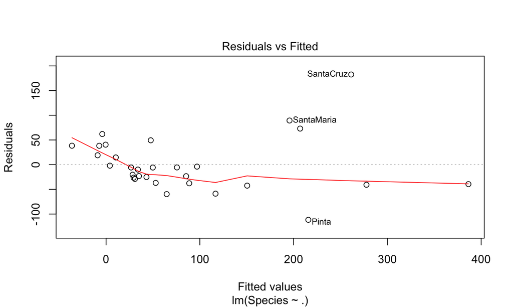

```r
modl <- lm(Species ~ . , d)
plot(modl, 1)
```

## Galapagos Data

### Square root transformation

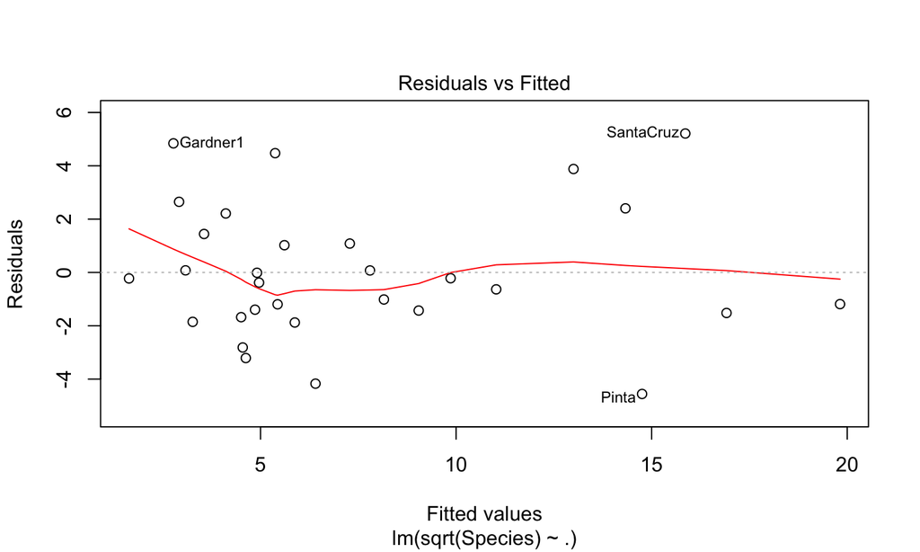

```r
modt <- lm(sqrt(Species) ~ . , d)
plot(modt, 1)
```

## Galapagos Data

### Square root transformation

```r
summary(modt)
```

```
##
## Call:
## lm(formula = sqrt(Species) ~ ., data = d)
##
## Residuals:
##     Min      1Q  Median      3Q     Max
## -4.5572 -1.4969 -0.3031  1.3527  5.2110
##
## Coefficients:
##               Estimate Std. Error t value Pr(>|t|)
## (Intercept)  3.3919243  0.8712678   3.893 0.000690 ***
## Area        -0.0019718  0.0010199  -1.933 0.065080 .
## Elevation    0.0164784  0.0024410   6.751 5.55e-07 ***
## Nearest      0.0249326  0.0479495   0.520 0.607844
## Scruz       -0.0134826  0.0097980  -1.376 0.181509
## Adjacent    -0.0033669  0.0008051  -4.182 0.000333 ***
## ---
## Signif. codes:  0 '***' 0.001 '**' 0.01 '*' 0.05 '.' 0.1 ' ' 1
##
## Residual standard error: 2.774 on 24 degrees of freedom
## Multiple R-squared:  0.7827, Adjusted R-squared:  0.7374
## F-statistic: 17.29 on 5 and 24 DF,  p-value: 2.874e-07
```

## Create Poisson Model

- If \(Y_i \sim Pois(\mu_i)\) what constraint is on \(\mu\)?
- \(\eta_i = x_i^T\beta\)
- \(log \mu_i = \eta_i = x_i^T\beta\)

\[ l(\beta) = \sum_{i = 1} ^ n (y_i x_i^T \beta - exp(x_i^T \beta) - log(y_i!)) \]

## Fit Poisson Model

```r
modp <- glm(Species ~ ., family=poisson, d)
summary(modp)
```

```
##
## Call:
## glm(formula = Species ~ ., family = poisson, data = d)
##
## Deviance Residuals:
##     Min       1Q   Median       3Q      Max
## -8.2752  -4.4966  -0.9443   1.9168  10.1849
##
## Coefficients:
##               Estimate Std. Error z value Pr(>|z|)
## (Intercept)  3.155e+00  5.175e-02  60.963  < 2e-16 ***
## Area        -5.799e-04  2.627e-05 -22.074  < 2e-16 ***
## Elevation    3.541e-03  8.741e-05  40.507  < 2e-16 ***
## Nearest      8.826e-03  1.821e-03   4.846 1.26e-06 ***
## Scruz       -5.709e-03  6.256e-04  -9.126  < 2e-16 ***
## Adjacent    -6.630e-04  2.933e-05 -22.608  < 2e-16 ***
## ---
## Signif. codes:  0 '***' 0.001 '**' 0.01 '*' 0.05 '.' 0.1 ' ' 1
##
## (Dispersion parameter for poisson family taken to be 1)
##
##     Null deviance: 3510.73  on 29  degrees of freedom
## Residual deviance:  716.85  on 24  degrees of freedom
## AIC: 889.68
##
## Number of Fisher Scoring iterations: 5
```

## Deviance

- You can use it the same way as before (goodness of fit and compare nested models)
- Deviance (or G-statistic)

\[ D = 2 \sum_{i = 1} ^ n (y_i log(y_i/ \hat \mu_i) - (y_i - \hat \mu_i)) \]

- Pearson’s \(X^2\)

\[ X^2 = \sum_{i = 1} ^ n\frac{(O-E)^2}{E} = \frac{(y_i - \hat \mu_i) ^ 2}{\hat \mu_i} \]

## Dispersed Poisson Model

## Overdispersion in Poisson

- Same issues as binomial - variance is tied to mean

```r
broom::glance(modp)
```

| null.deviance | df.null | logLik | AIC | BIC | deviance | df.residual | nobs |
| --- | --- | --- | --- | --- | --- | --- | --- |
| 3510.729 | 29 | -438.8384 | 889.6767 | 898.0839 | 716.8458 | 24 | 30 |

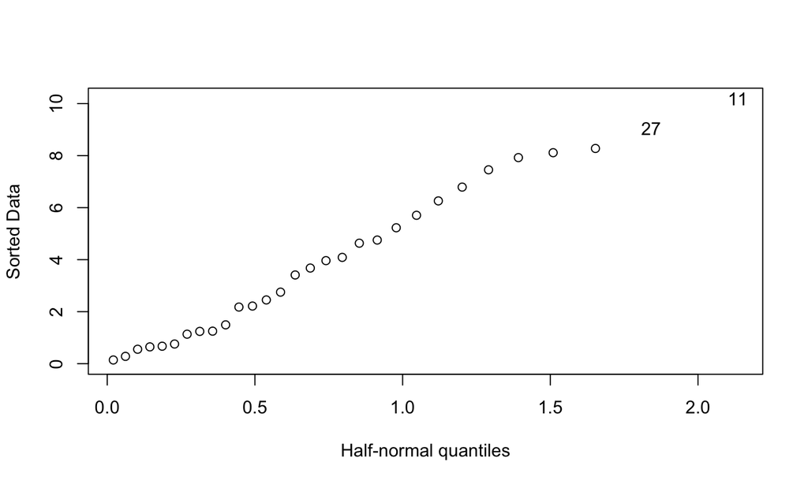

```r
halfnorm(residuals(modp))
```

## Variance vs Mean

- use \((y - \hat \mu)^2\) as an estimate of variance

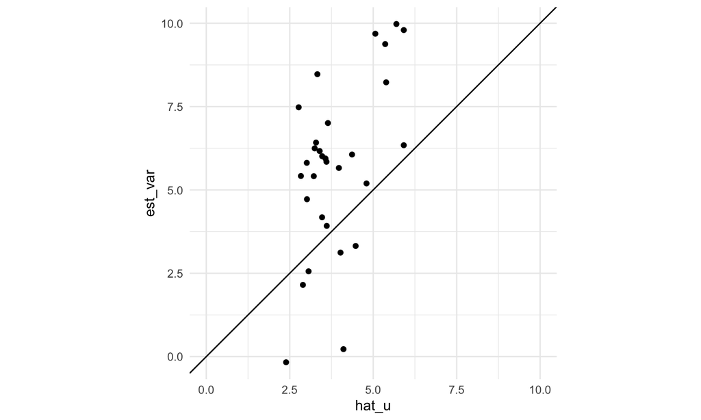

## Overdispersion

- What can we say about the point estimates for parameters in the model?
- What can we say about the standard error around those parameters?
- We can add dispersion parameter such that \(var \space Y = \phi\mu\)
- Estimate with:

\[ \hat \phi = \frac{X^2}{n - p} = \frac{\frac{(y_i - \hat \mu_i) ^ 2}{\hat \mu_i}}{n-p} \]

## Overdispersion Application

```r
dp <- sum(residuals(modp,type="pearson")^2)/modp$df.res
summary(modp, dispersion = dp)
```

```
##
## Call:
## glm(formula = Species ~ ., family = poisson, data = d)
##
## Deviance Residuals:
##     Min       1Q   Median       3Q      Max
## -8.2752  -4.4966  -0.9443   1.9168  10.1849
##
## Coefficients:
##               Estimate Std. Error z value Pr(>|z|)
## (Intercept)  3.1548079  0.2915897  10.819  < 2e-16 ***
## Area        -0.0005799  0.0001480  -3.918 8.95e-05 ***
## Elevation    0.0035406  0.0004925   7.189 6.53e-13 ***
## Nearest      0.0088256  0.0102621   0.860    0.390
## Scruz       -0.0057094  0.0035251  -1.620    0.105
## Adjacent    -0.0006630  0.0001653  -4.012 6.01e-05 ***
## ---
## Signif. codes:  0 '***' 0.001 '**' 0.01 '*' 0.05 '.' 0.1 ' ' 1
##
## (Dispersion parameter for poisson family taken to be 31.74914)
##
##     Null deviance: 3510.73  on 29  degrees of freedom
## Residual deviance:  716.85  on 24  degrees of freedom
## AIC: 889.68
##
## Number of Fisher Scoring iterations: 5
```

## Overdispersion Application

- you can use `quasipoisson` to do it all in one go
- use F test to compare nested models

## Rate Models

## Set up

- The number of variables may depend on a ‘size’ variable - but a binomial rate may not make sense
- Any ideas for examples?
- Some scaler (e.g. population or time)
- When may a binomial not make sense?
  - rate > 1
  - multiple events per row

## Gamma Radiation on Chromosomal Abnormalities

- outcome is the number of chromosomal abnormalities/cell

| doseamt/doserate | 0.1 | 0.25 | 0.5 | 1 | 1.5 | 2 | 2.5 | 3 | 4 |
| --- | --- | --- | --- | --- | --- | --- | --- | --- | --- |
| 1 | 0.05 | 0.05 | 0.07 | 0.07 | 0.06 | 0.07 | 0.07 | 0.07 | 0.07 |
| 2.5 | 0.16 | 0.28 | 0.29 | 0.32 | 0.38 | 0.41 | 0.41 | 0.37 | 0.44 |
| 5 | 0.48 | 0.82 | 0.90 | 0.88 | 1.23 | 1.32 | 1.34 | 1.24 | 1.43 |

## Gamma Radiation on Chromosomal Abnormalities

### Cont.

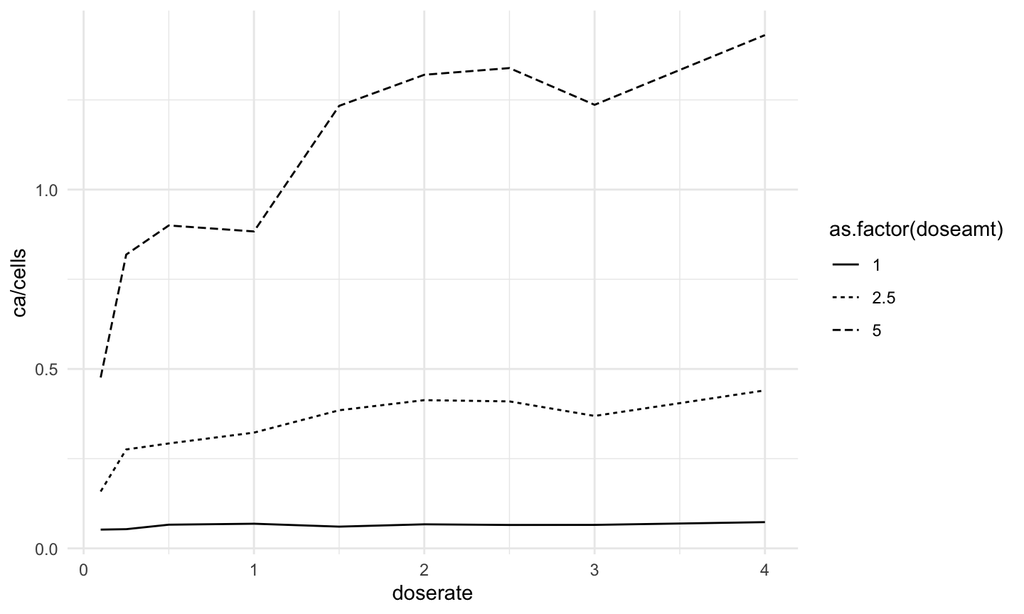

## Model

```
## [1] 0.9844421
```

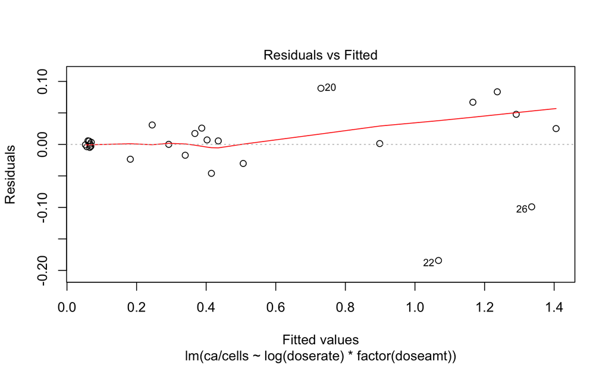

## Use Poisson

```r
dicentric$dosef <- factor(dicentric$doseamt)
pmod <- glm(ca ~ offset(log(cells)) +log(doserate)*dosef, family=poisson,data = dicentric)
summary(pmod)
```

```
##
## Call:
## glm(formula = ca ~ offset(log(cells)) + log(doserate) * dosef,
##     family = poisson, data = dicentric)
##
## Deviance Residuals:
##      Min        1Q    Median        3Q       Max
## -1.49101  -0.62473  -0.05078   0.76786   1.59115
##
## Coefficients:
##                        Estimate Std. Error z value Pr(>|z|)
## (Intercept)            -2.74671    0.03426 -80.165  < 2e-16 ***
## log(doserate)           0.07178    0.03518   2.041 0.041299 *
## dosef2.5                1.62542    0.04946  32.863  < 2e-16 ***
## dosef5                  2.76109    0.04349  63.491  < 2e-16 ***
## log(doserate):dosef2.5  0.16122    0.04830   3.338 0.000844 ***
## log(doserate):dosef5    0.19350    0.04243   4.561  5.1e-06 ***
## ---
## Signif. codes:  0 '***' 0.001 '**' 0.01 '*' 0.05 '.' 0.1 ' ' 1
##
## (Dispersion parameter for poisson family taken to be 1)
##
##     Null deviance: 4753.00  on 26  degrees of freedom
## Residual deviance:   21.75  on 21  degrees of freedom
## AIC: 209.16
##
## Number of Fisher Scoring iterations: 4
```

## How does offset work?

```r
pmod_no_inter <- glm(ca ~ offset(log(cells)) +log(doserate) + dosef, family=poisson,data = dicentric)
dicentric_fit <- dicentric
dicentric_fit$fitted <- fitted.values(pmod)
dicentric_fit$fitted_no_inter <- fitted.values(pmod_no_inter)
```

## Interaction Term

### Plot

```r
p <- ggplot(dicentric, aes(x = doserate, y = ca/cells, linetype = as.factor(doseamt))) +
  geom_line() +
  geom_line(data = dicentric_fit, aes(y = fitted/cells, color = "Interaction")) +
  geom_line(data = dicentric_fit, aes(y = fitted_no_inter/cells, color = "No Interaction")) +
  scale_x_log10() +
  scale_y_log10()
```

## Interaction Term

### Plot

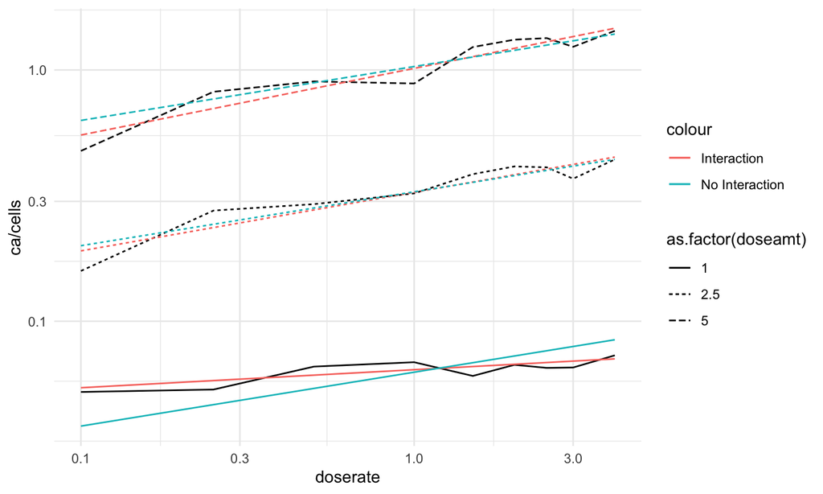

## Negative Binomial

## Setup

- given a series of independent trials, each with probability success p, let Z be the number of trials unl the kth success.

\[ P(Z = z) = \binom{z-1}{k-1}p^k(1-p)^{z-k} \\ z = k, k+1, ... \]

- reparameterize so that \(Y = Z-k\) and \(p = (1 + \alpha)^{-1}\)
- \(E Y = \mu = k\alpha\) and \(var Y = k\alpha + k \alpha^2 = \mu + \mu^2/k\)

## Solder Data

```r
data(solder, package="faraway")
modp <- glm(skips ~ . , family=poisson, data=solder)
c(deviance(modp), df.residual(modp))
```

```
## [1] 1829.002  882.000
```

## Fit model with fixed K

```r
library(MASS)
modn <- glm(skips ~ .,negative.binomial(1),solder)
summary(modn)
```

```
##
## Call:
## glm(formula = skips ~ ., family = negative.binomial(1), data = solder)
##
## Deviance Residuals:
##     Min       1Q   Median       3Q      Max
## -1.9628  -0.8021  -0.2373   0.3204   2.1097
##
## Coefficients:
##             Estimate Std. Error t value Pr(>|t|)
## (Intercept) -1.69933    0.16334 -10.404  < 2e-16 ***
## OpeningM     0.50854    0.08797   5.781 1.03e-08 ***
## OpeningS     1.99966    0.08069  24.783  < 2e-16 ***
## SolderThin   1.04894    0.06364  16.483  < 2e-16 ***
## MaskA3       0.65710    0.10463   6.280 5.29e-10 ***
## MaskA6       2.52649    0.12123  20.841  < 2e-16 ***
## MaskB3       1.27261    0.10780  11.806  < 2e-16 ***
## MaskB6       2.08026    0.10482  19.845  < 2e-16 ***
## PadTypeD6   -0.46118    0.13788  -3.345 0.000859 ***
## PadTypeD7    0.01608    0.13350   0.120 0.904185
## PadTypeL4    0.46883    0.13046   3.594 0.000344 ***
## PadTypeL6   -0.47115    0.13799  -3.414 0.000669 ***
## PadTypeL7   -0.29494    0.13620  -2.165 0.030618 *
## PadTypeL8   -0.08493    0.13432  -0.632 0.527372
## PadTypeL9   -0.52125    0.13854  -3.763 0.000179 ***
## PadTypeW4   -0.14250    0.13481  -1.057 0.290781
## PadTypeW9   -1.48361    0.15317  -9.686  < 2e-16 ***
## Panel        0.16932    0.03811   4.443 1.00e-05 ***
## ---
## Signif. codes:  0 '***' 0.001 '**' 0.01 '*' 0.05 '.' 0.1 ' ' 1
##
## (Dispersion parameter for Negative Binomial(1) family taken to be 0.5560534)
##
##     Null deviance: 1743.01  on 899  degrees of freedom
## Residual deviance:  558.67  on 882  degrees of freedom
## AIC: 3883.7
##
## Number of Fisher Scoring iterations: 9
```

## Fit model with parameter K

```r
modn <- glm.nb(skips ~ .,solder)
summary(modn)
```

```
##
## Call:
## glm.nb(formula = skips ~ ., data = solder, init.theta = 4.397157245,
##     link = log)
##
## Deviance Residuals:
##     Min       1Q   Median       3Q      Max
## -2.7376  -1.0068  -0.3834   0.4460   2.7829
##
## Coefficients:
##             Estimate Std. Error z value Pr(>|z|)
## (Intercept) -1.42245    0.14274  -9.965  < 2e-16 ***
## OpeningM     0.50294    0.07976   6.306 2.87e-10 ***
## OpeningS     1.91317    0.07152  26.750  < 2e-16 ***
## SolderThin   0.93932    0.05362  17.517  < 2e-16 ***
## MaskA3       0.58981    0.09651   6.112 9.87e-10 ***
## MaskA6       2.26734    0.10182  22.269  < 2e-16 ***
## MaskB3       1.21101    0.09637  12.566  < 2e-16 ***
## MaskB6       1.99037    0.09223  21.580  < 2e-16 ***
## PadTypeD6   -0.46592    0.11238  -4.146 3.38e-05 ***
## PadTypeD7   -0.03315    0.10673  -0.311 0.756114
## PadTypeL4    0.38268    0.10265   3.728 0.000193 ***
## PadTypeL6   -0.57844    0.11413  -5.068 4.01e-07 ***
## PadTypeL7   -0.36656    0.11094  -3.304 0.000953 ***
## PadTypeL8   -0.15890    0.10821  -1.468 0.141986
## PadTypeL9   -0.56600    0.11393  -4.968 6.77e-07 ***
## PadTypeW4   -0.20044    0.10873  -1.844 0.065255 .
## PadTypeW9   -1.56460    0.13621 -11.486  < 2e-16 ***
## Panel        0.16369    0.03139   5.214 1.85e-07 ***
## ---
## Signif. codes:  0 '***' 0.001 '**' 0.01 '*' 0.05 '.' 0.1 ' ' 1
##
## (Dispersion parameter for Negative Binomial(4.3972) family taken to be 1)
##
##     Null deviance: 4043.3  on 899  degrees of freedom
## Residual deviance: 1008.3  on 882  degrees of freedom
## AIC: 3683.3
##
## Number of Fisher Scoring iterations: 1
##
##
##               Theta:  4.397
##           Std. Err.:  0.495
##
##  2 x log-likelihood:  -3645.309
```

## Zero Inflated Count Models

## Set up

- We often see situations where there are more 0’s than would be expected by either of these models.
- We consider a sample of 915 biochemistry graduate students as analyzed by Long (1990). The response is the number of articles produced during the last three years of the PhD.We are interested in how this is related to the gender, marital status, number of children, prestige of the department and productivity of the advisor of the student.

```r
library(pscl)
modp <- glm(art ~ ., data=bioChemists, family=poisson)
summary(modp)
```

```
##
## Call:
## glm(formula = art ~ ., family = poisson, data = bioChemists)
##
## Deviance Residuals:
##     Min       1Q   Median       3Q      Max
## -3.5672  -1.5398  -0.3660   0.5722   5.4467
##
## Coefficients:
##              Estimate Std. Error z value Pr(>|z|)
## (Intercept)  0.304617   0.102981   2.958   0.0031 **
## femWomen    -0.224594   0.054613  -4.112 3.92e-05 ***
## marMarried   0.155243   0.061374   2.529   0.0114 *
## kid5        -0.184883   0.040127  -4.607 4.08e-06 ***
## phd          0.012823   0.026397   0.486   0.6271
## ment         0.025543   0.002006  12.733  < 2e-16 ***
## ---
## Signif. codes:  0 '***' 0.001 '**' 0.01 '*' 0.05 '.' 0.1 ' ' 1
##
## (Dispersion parameter for poisson family taken to be 1)
##
##     Null deviance: 1817.4  on 914  degrees of freedom
## Residual deviance: 1634.4  on 909  degrees of freedom
## AIC: 3314.1
##
## Number of Fisher Scoring iterations: 5
```